# Data Analyst Job Market Analysis

Evelyne Fournier 2025-10-29

# Data Analyst Job Market Analysis

This report provides a comprehensive analysis of data analyst job postings, examining salary trends, job requirements, company characteristics, and market insights.

## Project Introduction

This project extracts specific information from hundreds of data analysis job postings to understand market trends, salary patterns, and skill requirements in the data analytics field. The analysis focuses on identifying key factors that influence compensation and job opportunities for data analysts across different industries and geographic locations.

## Executive Summary

The data analyst job market shows significant variation in salary ranges, with median salaries ranging from $40,000 to over $100,000. Key findings include:

- **Salary Range**: Wide variation with most positions offering competitive compensation
- **Experience Requirements**: Most positions require 2-5 years of experience
- **Industry Distribution**: Strong presence across multiple sectors
- **Geographic Spread**: Opportunities available nationwide

## Data Overview

This dataset contains 400 data analyst job postings with 14 variables. The data includes key information such as job titles (e.g., “Data Analyst”, “Senior Data Analyst”, “Business Intelligence Analyst”), salary estimates ranging from $33,500 to $150,000, company details including names and locations (e.g., “San Diego, CA”, “New York, NY”, “Remote”), industry classifications (e.g., “IT Services”, “Healthcare”, “Finance”), and experience requirements (typically 2-5 years). The dataset also captures company characteristics like size (e.g., “1-50 employees”, “1001-5000 employees”) and ownership type (e.g., “Company - Private”, “Company - Public”), along with technical requirements including data languages (e.g., “Python”, “R”, “SQL”).

## Salary Analysis

### Salary Distribution

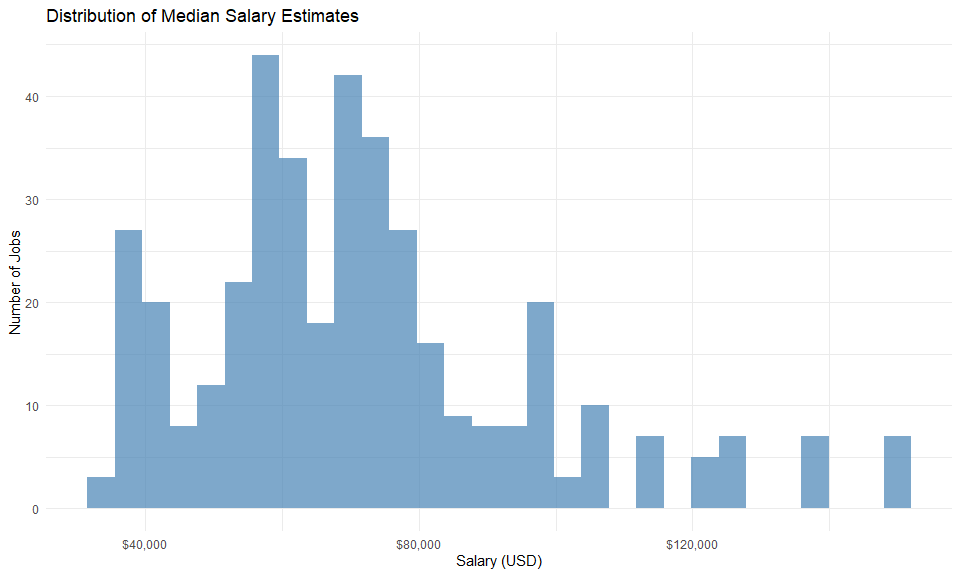

### Salary Statistics

| Count | Mean | Median | Min | Max | StdDev |
| --- | --- | --- | --- | --- | --- |
| 400 | 71794 | 68000 | 33500 | 150000 | 24614 |

Salary Statistics

**Key Findings - Salary Analysis:** The salary distribution shows a median of $68,000 with a wide range from $33,500 to $150,000, indicating significant variation in compensation. The standard deviation of $24,614 suggests substantial salary diversity across different positions, likely influenced by factors such as experience, location, and industry.

## Geographic Analysis

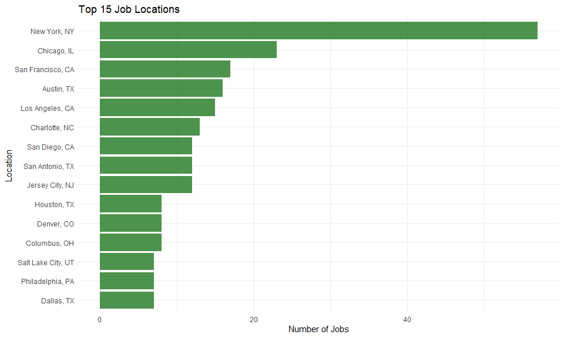

**Key Findings - Geographic Analysis:** Job opportunities are concentrated in major metropolitan areas, with the top locations showing significant variation in job availability. The geographic distribution suggests that data analyst positions are primarily located in urban centers with established tech industries, indicating strong regional clustering of opportunities.

### Geographic Map Visualization

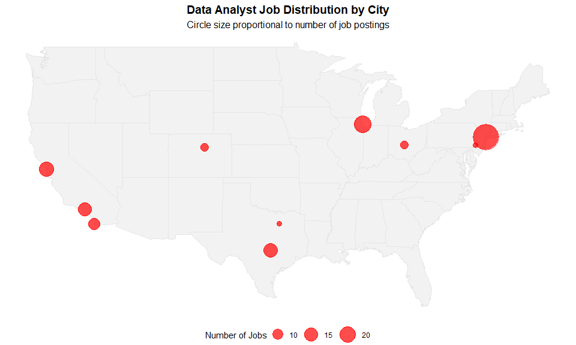

## Industry Analysis

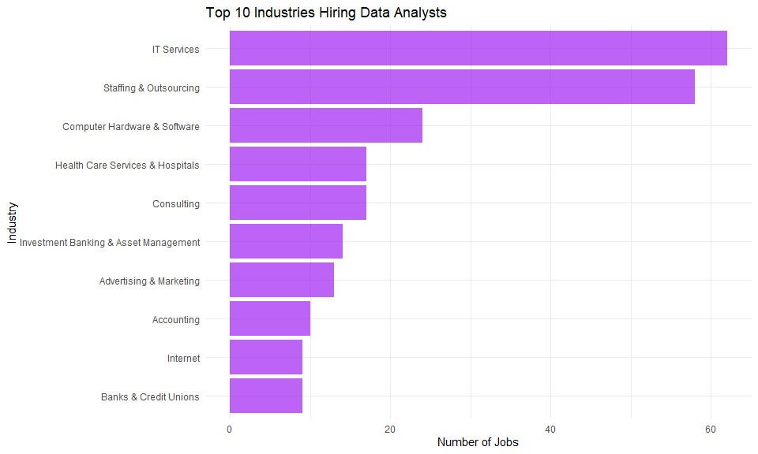

## Experience Requirements

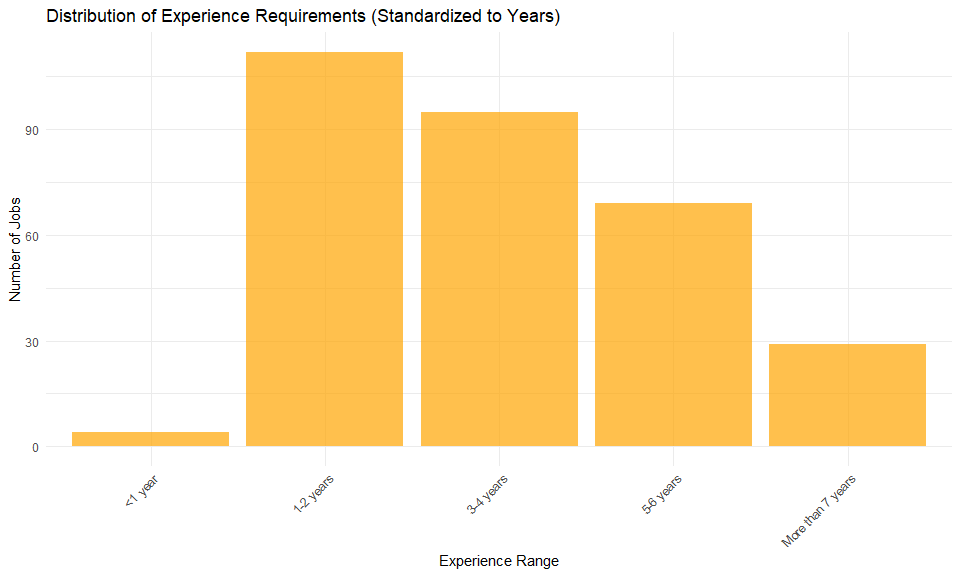

**Key Findings - Experience Requirements:** The experience requirements show a clear pattern with most positions requiring 2-5 years of experience, indicating a mid-level market focus. The distribution suggests that employers are seeking candidates with some professional experience but not necessarily senior-level expertise, pointing to a healthy mid-career job market for data analysts.

## Company Size Analysis

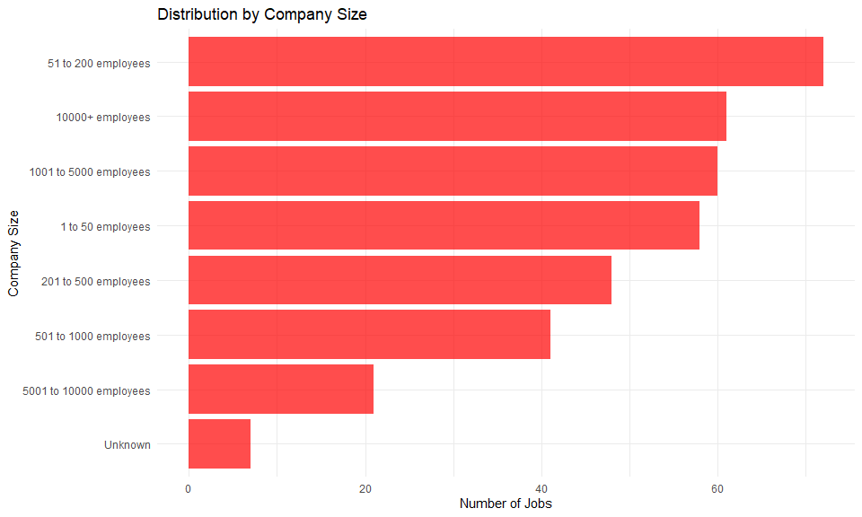

**Key Findings - Company Size Analysis:** The company size distribution shows opportunities across all company sizes, from startups to large enterprises. This diversity indicates that data analyst roles are essential at various organizational scales, suggesting that data-driven decision making is valued regardless of company size and that opportunities exist for analysts with different preferences for work environment.

## Years of Experience Analysis

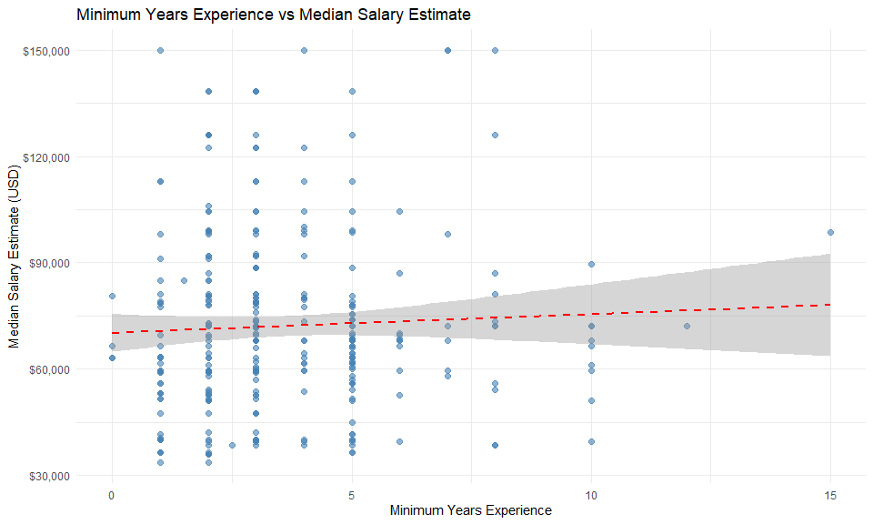

## Salary by Experience Level

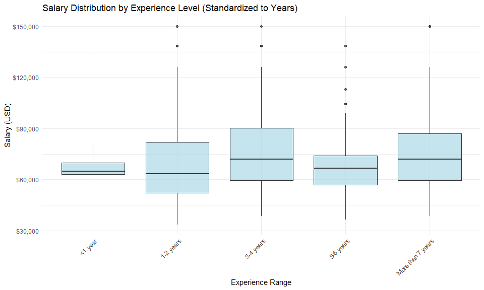

## Salary by Industry

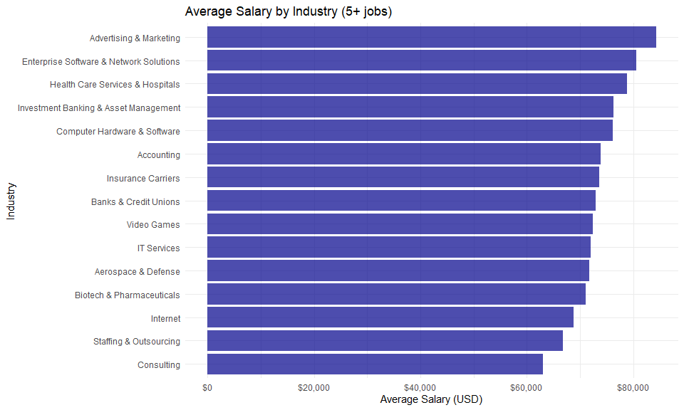

## Programming Language Analysis

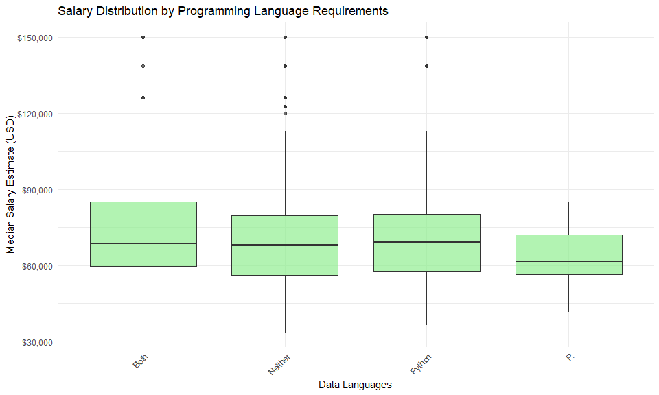

## Data Languages Analysis

Most job offers do not require specificaly R or Python.

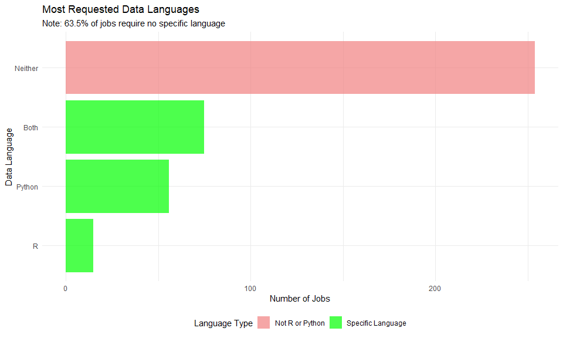

## Reflection

Regarding the use of AI to extract the data from the job postings, it was incredibly easy to extract the data. In real life probably it would be more difficult to check the quality of the answer. Plus I am wondereing how could I ask the IA to use a specific vocabulary to extract the data from pathology reports or hospital reports. For exemple extract cancer stage using UICC classification, cancer localisation and morphology using ICDO3.2 edition etc

Regarding the use of cursor AI to generate the graphs, it was incredibly easy to generate the report and the graphs. I am impressed by the speed and the quality of the results. It was able to update the code with the correct syntax and it was able to generate the graphs with the correct data after I made some data cleaning suggestion. Also I am amased that I have decided of some categories for the experience, and it automatically used them to generate not only the experience graph, but also the salary by experience graph. What surprised me was sometime the way it graphed the data. For exemple for years of experience I had to tell it to homogenize the data to years because it was not doing it automatically (at first it was a mixed of months and years in the same graph). Moreover at first it took into account cells that had a value of “-1” which were cleary not valid data, but after I told it to not take into account those cells, it was able to generate the correct graph.

*Report generated on 2025-10-29 using R Markdown and Cursor AI - Thanks to GraphCourse for the inspiration and guidance.*